# 6026 Final Project

Yixin Li, Elena Liu

2022-04-30

## Introduction

Model selection: When variable number p is too big, using all the variables may subject to poor predictive performance.

A Poisson distribution is a tool that helps to predict the probability of certain events happening when you know how often the event has occurred. We will use Poisson Regression to estimate the bottles of wine sold based on independent variables.

Even though RSS decreases as the number of participating variables for Poisson regression, it may result overfitting, and may not have a promising predictive ability on another sample set from the same population.

Overfitting: the sample size n is smaller than the number of predictors p. Non-informative predictors may then be caused consequently, and these predictors may not contribute to the outcome variable.

There are two alternative methods for better dealing with the situation:

1. Best Subset Selection (bestglm()) with Poisson distribution)
- bestglm uses the simple exhaustive search algorithm for glm and the regsubsets function in the leaps package to find the glm models with smallest sum of squares or deviances for size k = 0, 1,…, p. Size k = 0 corresponds to intercept only. The exhaustive search requires more computer time but this is usually not an issue when p<=10.
2. Stepwise Selection: fits one model at a time with p-k models (k = 1,…,p-1 / k = p, p-1, p-2,…, 1) with k iterations.
- Forward Stepwise Selection: starting at a null model M0, which has no predictors, and increase the predictor number Mk with one additional parameter at one iteration.
- Backward Stepwise Selection: starting with a full model, which has all p predictors, and decrease the predictor number Mk with one less parameter at one iteration.
- Select the best model with cross validation.
- Stepwise selection in the MASS package to find the optimal model backward or forward based on AIC and BIC values. The function stepAIC() can be adjusted to trace the value of BIC simply convert k value as log(nrow(data)).

Cross Validation: AIC and BIC are calculated from the (-2) times the maximized value of likelihood (LL).

- AIC: 2*k – 2*LL
  - More permissive with model complexity.
  - Suitable for prediction.
- BIC: ln(n)*k – 2*LL
  - More penalized with model complexity.
  - Suitable for explanation.

Pro and Con for best subset selection:

- Pro: the accuracy of best subset selection is higher than stepwise selection.
- Con: Best subset selection is computational demanding, even worse with other regression methods, like logistic regression.

Pro and Con for stepwise selection:

- Pro: Stepwise selection is much more efficient than best subset selection with much less computational demanding. Additionally, stepwise selection is very informative in eliminating non-informative predictors.
- Con: Stepwise selection may result an inflation of Type I error for significance predictors testing since some predictors are bound to be significant by chance when fitting so many models. Therefore, the statistical significance of coefficients selected from this method is suspicious when explaining the model. Also, stepwise selection is very much dependent on functional form assumption. Therefore, for any non-linear regression, all the predictors will be assumed linearly related to the outcome unless they are specified in the model.

## Data Description

The white wine dataset was collected to predict wine demand at a restaurant by using factors such as origin, variety, sensory descriptors and price. This dataset has 23 columns and 551 rows. The columns include IDs of white wines which is a nominal variable. Price X, a numerical predictor and 20 categorical predictors. The predictors we will be using in our model selection are described below:

1. Y = bottles sold
2. X = price
3. D1 = indicator for having the lowest price in a menu 4. category
4. D2 = indicator for being available by the glass
5. D3 = indicator for Oregon Chardonnay (ref: California 7. Chardonnay)
6. D4 = indicator for Oregon Pinot Gris (ref: California Chardonnay)
7. D5 = indicator for California other (ref: California Chardonnay)
8. D6 = indicator for Northwest other (ref: California Chardonnay
9. D7 = indicator for French (ref: California Chardonnay)
10. D8 = indicator for body
11. D9 = indicator for finish
12. D10 = indicator for oak
13. D11 = indicator for rich
14. D12 = indicator for spice
15. D13 = indicator for buttery
16. D14 = indicator for creamy
17. D15 = indicator for dry
18. D16 = indicator for honey
19. D17 = indicator for melon
20. D18 = indicator for citrus
21. D19 = indicator for other tree fruit
22. D20 = indicator for tropical fruit

The goal for our project is to find the best selected model, estimate the performance of the model, investigate the relationship between variables, and compare the step chosen model and the full model. Finally, we will check several model assumptions including normality, homogeneity of variance, over-disperse and the validity of the deviance goodness.

Before model selection and analysis, we will first preprocess our dataset by converting D1 - D20 to categorical data because R will recognize it as numerical. Then, ID will be removed to build a regression model regarding Y and all predictors.

The dependent variables are not continuous and y was counted in a specific period , so poisson distribution will be used in our project. In order to find the best model, we will use glm and stepwise methods including forward and backward selection with AIC and BIC. Then, we will conduct cross validation to decide to keep which model. Based on the best model, we will use effect size to evaluate the relationship between wine price and bottles sold. Explanatory power is for us to check how much variation is explained by each model, so that we can conclude which model is better. Finally, model assumptions will be checked to evaluate the model and check if the model is appropriate for prediction.

## Analysis

#### Packages

```r
library(bestglm)
library(foreign)
library(MASS)
library(DHARMa)
```

#### Data Preprocessing

```r
#Import data
wine=read.spss(file.choose(), to.data.frame=T)
# Check out the data
head(wine)
```

```
##   ID  Y  X D1 D2 D3 D4 D5 D6 D7 D8 D9 D10 D11 D12 D13 D14 D15 D16 D17 D18 D19
## 1 47 15 19  0  1  0  0  0  0  0  0  0   0   0   0   0   0   0   0   0   0   0
## 2 47 17 19  0  1  0  0  0  0  0  0  0   0   0   0   0   0   0   0   0   0   0
## 3 47  6 19  0  1  0  0  0  0  0  0  0   0   0   0   0   0   0   0   0   0   0
## 4 47 12 19  0  1  0  0  0  0  0  0  0   0   0   0   0   0   0   0   0   0   0
## 5 47  9 19  0  1  0  0  0  0  0  0  0   0   0   0   0   0   0   0   0   0   0
## 6 47 11 19  0  1  0  0  0  0  0  0  0   0   0   0   0   0   0   0   0   0   0
##   D20
## 1   0
## 2   0
## 3   0
## 4   0
## 5   0
## 6   0
```

```r
summary(wine)
```

```
##        ID           Y                X               D1
##  Min.   :47   Min.   : 0.000   Min.   :13.00   Min.   :0.0000
##  1st Qu.:54   1st Qu.: 0.000   1st Qu.:19.00   1st Qu.:0.0000
##  Median :61   Median : 0.000   Median :27.00   Median :0.0000
##  Mean   :61   Mean   : 1.383   Mean   :26.97   Mean   :0.1379
##  3rd Qu.:68   3rd Qu.: 1.000   3rd Qu.:35.00   3rd Qu.:0.0000
##  Max.   :75   Max.   :17.000   Max.   :48.00   Max.   :1.0000
##        D2               D3               D4                D5
##  Min.   :0.0000   Min.   :0.0000   Min.   :0.00000   Min.   :0.0000
##  1st Qu.:0.0000   1st Qu.:0.0000   1st Qu.:0.00000   1st Qu.:0.0000
##  Median :0.0000   Median :0.0000   Median :0.00000   Median :0.0000
##  Mean   :0.1724   Mean   :0.2069   Mean   :0.06897   Mean   :0.1379
##  3rd Qu.:0.0000   3rd Qu.:0.0000   3rd Qu.:0.00000   3rd Qu.:0.0000
##  Max.   :1.0000   Max.   :1.0000   Max.   :1.00000   Max.   :1.0000
##        D6               D7               D8               D9
##  Min.   :0.0000   Min.   :0.0000   Min.   :0.0000   Min.   :0.0000
##  1st Qu.:0.0000   1st Qu.:0.0000   1st Qu.:0.0000   1st Qu.:0.0000
##  Median :0.0000   Median :0.0000   Median :0.0000   Median :0.0000
##  Mean   :0.1724   Mean   :0.2069   Mean   :0.3793   Mean   :0.1034
##  3rd Qu.:0.0000   3rd Qu.:0.0000   3rd Qu.:1.0000   3rd Qu.:0.0000
##  Max.   :1.0000   Max.   :1.0000   Max.   :1.0000   Max.   :1.0000
##       D10              D11              D12              D13
##  Min.   :0.0000   Min.   :0.0000   Min.   :0.0000   Min.   :0.0000
##  1st Qu.:0.0000   1st Qu.:0.0000   1st Qu.:0.0000   1st Qu.:0.0000
##  Median :0.0000   Median :0.0000   Median :0.0000   Median :0.0000
##  Mean   :0.1034   Mean   :0.3103   Mean   :0.2069   Mean   :0.2069
##  3rd Qu.:0.0000   3rd Qu.:1.0000   3rd Qu.:0.0000   3rd Qu.:0.0000
##  Max.   :1.0000   Max.   :1.0000   Max.   :1.0000   Max.   :1.0000
##       D14              D15              D16              D17
##  Min.   :0.0000   Min.   :0.0000   Min.   :0.0000   Min.   :0.0000
##  1st Qu.:0.0000   1st Qu.:0.0000   1st Qu.:0.0000   1st Qu.:0.0000
##  Median :0.0000   Median :0.0000   Median :0.0000   Median :0.0000
##  Mean   :0.1034   Mean   :0.2759   Mean   :0.1379   Mean   :0.2414
##  3rd Qu.:0.0000   3rd Qu.:1.0000   3rd Qu.:0.0000   3rd Qu.:0.0000
##  Max.   :1.0000   Max.   :1.0000   Max.   :1.0000   Max.   :1.0000
##       D18              D19              D20
##  Min.   :0.0000   Min.   :0.0000   Min.   :0.0000
##  1st Qu.:0.0000   1st Qu.:0.0000   1st Qu.:0.0000
##  Median :0.0000   Median :0.0000   Median :0.0000
##  Mean   :0.2069   Mean   :0.2069   Mean   :0.2414
##  3rd Qu.:0.0000   3rd Qu.:0.0000   3rd Qu.:0.0000
##  Max.   :1.0000   Max.   :1.0000   Max.   :1.0000
```

```r
# Convert variables D1-D20 to categorical
for (j in 4:23) wine[,j] = factor(wine[,j])

summary(wine)
```

```
##        ID           Y                X         D1      D2      D3      D4
##  Min.   :47   Min.   : 0.000   Min.   :13.00   0:475   0:456   0:437   0:513
##  1st Qu.:54   1st Qu.: 0.000   1st Qu.:19.00   1: 76   1: 95   1:114   1: 38
##  Median :61   Median : 0.000   Median :27.00
##  Mean   :61   Mean   : 1.383   Mean   :26.97
##  3rd Qu.:68   3rd Qu.: 1.000   3rd Qu.:35.00
##  Max.   :75   Max.   :17.000   Max.   :48.00
##  D5      D6      D7      D8      D9      D10     D11     D12     D13
##  0:475   0:456   0:437   0:342   0:494   0:494   0:380   0:437   0:437
##  1: 76   1: 95   1:114   1:209   1: 57   1: 57   1:171   1:114   1:114
##
##
##
##
##  D14     D15     D16     D17     D18     D19     D20
##  0:494   0:399   0:475   0:418   0:437   0:437   0:418
##  1: 57   1:152   1: 76   1:133   1:114   1:114   1:133
##
##
##
##
```

```r
# Remove the ID
wine = wine[,-1]
```

#### Data Visualization

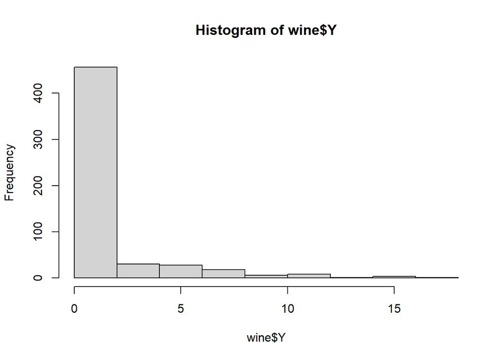

```r
hist(wine$Y)
```

```r
mean(wine$Y)
```

```
## [1] 1.38294
```

```r
var(wine$Y)
```

```
## [1] 7.549454
```

We use poisson regression because the dependent variable is not continuous and from the histogram, we can see that it is not normally distributed. By comparing the mean and variance of the dependent variable, we found that the variance is greater than the mean which indicates that an over-dispersion will occur in the model. Also, y variable is bottles sold which was counted in a specific period, so Poisson distribution is more appropriate here. We use glm() instead of bestglm() here because the data is non-Gaussian and predictors must be less or equal to 15 but the predictors for our dataset is 21.

#### GLM

```r
p1 = glm(Y ~ ., family = "poisson", data = wine)
summary(p1)
```

```
##
## Call:
## glm(formula = Y ~ ., family = "poisson", data = wine)
##
## Deviance Residuals:
##     Min       1Q   Median       3Q      Max
## -3.0383  -0.7851  -0.3908   0.0962   3.3255
##
## Coefficients:
##             Estimate Std. Error z value Pr(>|z|)
## (Intercept)  2.72639    0.69085   3.946 7.93e-05 ***
## X           -0.10514    0.02898  -3.628 0.000285 ***
## D11         -1.14591    0.37282  -3.074 0.002115 **
## D21          1.63993    0.23199   7.069 1.56e-12 ***
## D31         -1.38458    0.16627  -8.327  < 2e-16 ***
## D41         -0.83931    0.12752  -6.582 4.65e-11 ***
## D51         -1.04371    0.17686  -5.901 3.60e-09 ***
## D61         -1.02050    0.19133  -5.334 9.62e-08 ***
## D71         -1.86373    0.53222  -3.502 0.000462 ***
## D81         -0.71086    0.38288  -1.857 0.063364 .
## D91         -0.18541    0.52048  -0.356 0.721662
## D101         1.01609    0.38483   2.640 0.008281 **
## D111         0.45177    0.36025   1.254 0.209826
## D121        -0.11134    0.32808  -0.339 0.734338
## D131         0.25282    0.42108   0.600 0.548229
## D141         1.21592    0.41211   2.950 0.003173 **
## D151         0.58429    0.23230   2.515 0.011895 *
## D161         0.09414    0.30596   0.308 0.758308
## D171        -0.11398    0.33488  -0.340 0.733584
## D181        -0.82829    0.36236  -2.286 0.022266 *
## D191         0.24458    0.40023   0.611 0.541125
## D201        -0.14155    0.28748  -0.492 0.622438
## ---
## Signif. codes:  0 '***' 0.001 '**' 0.01 '*' 0.05 '.' 0.1 ' ' 1
##
## (Dispersion parameter for poisson family taken to be 1)
##
##     Null deviance: 2046.92  on 550  degrees of freedom
## Residual deviance:  492.17  on 529  degrees of freedom
## AIC: 1123.1
##
## Number of Fisher Scoring iterations: 6
```

D9, D11, D12, D13, D16, D17, D19 and D20 are insignificant variables, so we will build a model without these insignificant variable.

```r
summary(p2 <- glm(Y ~ . -D9 -D11- D12- D13- D16- D17- D19- D20, family="poisson", data = wine))
```

```
##
## Call:
## glm(formula = Y ~ . - D9 - D11 - D12 - D13 - D16 - D17 - D19 -
##     D20, family = "poisson", data = wine)
##
## Deviance Residuals:
##     Min       1Q   Median       3Q      Max
## -3.0281  -0.7714  -0.3845   0.1014   3.3860
##
## Coefficients:
##             Estimate Std. Error z value Pr(>|z|)
## (Intercept)  2.20418    0.43073   5.117 3.10e-07 ***
## X           -0.08379    0.01465  -5.721 1.06e-08 ***
## D11         -0.91202    0.25836  -3.530 0.000415 ***
## D21          1.75508    0.18526   9.474  < 2e-16 ***
## D31         -1.30936    0.13868  -9.442  < 2e-16 ***
## D41         -0.84443    0.12566  -6.720 1.82e-11 ***
## D51         -0.95751    0.13477  -7.105 1.20e-12 ***
## D61         -0.90965    0.14945  -6.087 1.15e-09 ***
## D71         -1.79113    0.44016  -4.069 4.72e-05 ***
## D81         -0.76686    0.24156  -3.175 0.001501 **
## D101         1.03471    0.34408   3.007 0.002637 **
## D141         1.10486    0.25041   4.412 1.02e-05 ***
## D151         0.64841    0.19522   3.321 0.000896 ***
## D181        -0.85777    0.27218  -3.152 0.001624 **
## ---
## Signif. codes:  0 '***' 0.001 '**' 0.01 '*' 0.05 '.' 0.1 ' ' 1
##
## (Dispersion parameter for poisson family taken to be 1)
##
##     Null deviance: 2046.92  on 550  degrees of freedom
## Residual deviance:  495.23  on 537  degrees of freedom
## AIC: 1110.2
##
## Number of Fisher Scoring iterations: 6
```

The predictors are all significant now, and we can notice that the AIC for the reduced model is 1110.2 which is smaller than the full model, i.e. 1123.1, so we decided that we will delete the insignificant variables at this stage.

Then, we will compare the two models by using Chi-Squared test to check which model is the best model. The null hypothesis is the two models are statistically the same, so we will use the reduced model. The alternative hypothesis is the two models are not statistically the same, we will use the full model.

```r
anova(p2, p1, test="Chisq")
```

```
## Analysis of Deviance Table
##
## Model 1: Y ~ (X + D1 + D2 + D3 + D4 + D5 + D6 + D7 + D8 + D9 + D10 + D11 +
##     D12 + D13 + D14 + D15 + D16 + D17 + D18 + D19 + D20) - D9 -
##     D11 - D12 - D13 - D16 - D17 - D19 - D20
## Model 2: Y ~ X + D1 + D2 + D3 + D4 + D5 + D6 + D7 + D8 + D9 + D10 + D11 +
##     D12 + D13 + D14 + D15 + D16 + D17 + D18 + D19 + D20
##   Resid. Df Resid. Dev Df Deviance Pr(>Chi)
## 1       537     495.23
## 2       529     492.17  8   3.0502   0.9312
```

From the anova table, we can see that the p-value is .9312 which is greater than 0.05. Thus, we fail to reject the null hypothesis, which means we do not reject the coefficients associated with the insignificant variables are zero. We conclude that the two models are statistically the same. In that case, we will use the simper model, which is the one we drop the insignificant predictors. The best model have 13 variables.

#### Stepwise Method

We will use stepwise method by applying forward and backward selection on variables to find the best selected model. In forward selection, we will choose the variable with best predicting ability and use that variable to find the next best predicting variable until no variables can improve the model. In backward selection, we will first fit the full model and then remove insignificant variables one by one until the rest variables are all having predicting ability.

We build a smallest model for forward selection and a full model for backward selection

```r
# Smallest model with no predictors
min.model <- glm(Y ~ 1, family = "poisson", data = wine)

# full model with all predictors
max.model <- glm(Y ~ ., family = "poisson", data = wine)




# The scope of search indicates that the smallest model only consists the coefficient of intercept and the full model included the coefficient for intercepts and all variables.
scp <- list(lower = min.model, upper = max.model)
```

```r
# AIC
# Forward Selection
fwd <- stepAIC(min.model, direction = 'forward', scope = scp, trace = F)
summary(fwd)
```

```
##
## Call:
## glm(formula = Y ~ D2 + D7 + D3 + D8 + D4 + D5 + D6 + X + D1 +
##     D18 + D14 + D15 + D10, family = "poisson", data = wine)
##
## Deviance Residuals:
##     Min       1Q   Median       3Q      Max
## -3.0281  -0.7714  -0.3845   0.1014   3.3860
##
## Coefficients:
##             Estimate Std. Error z value Pr(>|z|)
## (Intercept)  2.20418    0.43073   5.117 3.10e-07 ***
## D21          1.75508    0.18526   9.474  < 2e-16 ***
## D71         -1.79113    0.44016  -4.069 4.72e-05 ***
## D31         -1.30936    0.13868  -9.442  < 2e-16 ***
## D81         -0.76686    0.24156  -3.175 0.001501 **
## D41         -0.84443    0.12566  -6.720 1.82e-11 ***
## D51         -0.95751    0.13477  -7.105 1.20e-12 ***
## D61         -0.90965    0.14945  -6.087 1.15e-09 ***
## X           -0.08379    0.01465  -5.721 1.06e-08 ***
## D11         -0.91202    0.25836  -3.530 0.000415 ***
## D181        -0.85777    0.27218  -3.152 0.001624 **
## D141         1.10486    0.25041   4.412 1.02e-05 ***
## D151         0.64841    0.19522   3.321 0.000896 ***
## D101         1.03471    0.34408   3.007 0.002637 **
## ---
## Signif. codes:  0 '***' 0.001 '**' 0.01 '*' 0.05 '.' 0.1 ' ' 1
##
## (Dispersion parameter for poisson family taken to be 1)
##
##     Null deviance: 2046.92  on 550  degrees of freedom
## Residual deviance:  495.23  on 537  degrees of freedom
## AIC: 1110.2
##
## Number of Fisher Scoring iterations: 6
```

```r
fwd$coefficients
```

```
## (Intercept)         D21         D71         D31         D81         D41
##  2.20417514  1.75507757 -1.79112789 -1.30935722 -0.76685658 -0.84442879
##         D51         D61           X         D11        D181        D141
## -0.95751148 -0.90965072 -0.08379398 -0.91201509 -0.85776780  1.10486114
##        D151        D101
##  0.64841077  1.03470922
```

```r
# By extracting the coefficients of predictors, we can see that there are 13 predictors are significant or contribute to the model.
# Y ~ D2 + D7 + D3 + D8 + D4 + D5 + D6 + X + D1 + D18 + D14 + D15 + D10
#AIC = 1110.2

# Backward Selection
bwd <- stepAIC(max.model,
               direction = 'backward',
               scope = scp, trace = F)
summary(bwd)
```

```
##
## Call:
## glm(formula = Y ~ X + D1 + D2 + D3 + D4 + D5 + D6 + D7 + D8 +
##     D10 + D14 + D15 + D18, family = "poisson", data = wine)
##
## Deviance Residuals:
##     Min       1Q   Median       3Q      Max
## -3.0281  -0.7714  -0.3845   0.1014   3.3860
##
## Coefficients:
##             Estimate Std. Error z value Pr(>|z|)
## (Intercept)  2.20418    0.43073   5.117 3.10e-07 ***
## X           -0.08379    0.01465  -5.721 1.06e-08 ***
## D11         -0.91202    0.25836  -3.530 0.000415 ***
## D21          1.75508    0.18526   9.474  < 2e-16 ***
## D31         -1.30936    0.13868  -9.442  < 2e-16 ***
## D41         -0.84443    0.12566  -6.720 1.82e-11 ***
## D51         -0.95751    0.13477  -7.105 1.20e-12 ***
## D61         -0.90965    0.14945  -6.087 1.15e-09 ***
## D71         -1.79113    0.44016  -4.069 4.72e-05 ***
## D81         -0.76686    0.24156  -3.175 0.001501 **
## D101         1.03471    0.34408   3.007 0.002637 **
## D141         1.10486    0.25041   4.412 1.02e-05 ***
## D151         0.64841    0.19522   3.321 0.000896 ***
## D181        -0.85777    0.27218  -3.152 0.001624 **
## ---
## Signif. codes:  0 '***' 0.001 '**' 0.01 '*' 0.05 '.' 0.1 ' ' 1
##
## (Dispersion parameter for poisson family taken to be 1)
##
##     Null deviance: 2046.92  on 550  degrees of freedom
## Residual deviance:  495.23  on 537  degrees of freedom
## AIC: 1110.2
##
## Number of Fisher Scoring iterations: 6
```

```r
bwd$coefficients
```

```
## (Intercept)           X         D11         D21         D31         D41
##  2.20417514 -0.08379398 -0.91201509  1.75507757 -1.30935722 -0.84442879
##         D51         D61         D71         D81        D101        D141
## -0.95751148 -0.90965072 -1.79112789 -0.76685658  1.03470922  1.10486114
##        D151        D181
##  0.64841077 -0.85776780
```

```r
# By applying backward selection with AIC, we found that there are 13 predictors contribute to the model.
# The best selected model for backward selection with AIC is
# Y ~ X + D1 + D2 + D3 + D4 + D5 + D6 + D7 + D8 + D10 + D14 + D15 + D18
#AIC = 1110.2


# BIC:
# Forward Selection
fwd2 <- stepAIC(min.model,
                k = log(nrow(wine)),
                direction = 'forward',
                scope = scp,
                trace = F)
summary(fwd2)
```

```
##
## Call:
## glm(formula = Y ~ D2 + D7 + D3 + D8 + D4 + D5 + D6 + X + D1 +
##     D18 + D14 + D15 + D10, family = "poisson", data = wine)
##
## Deviance Residuals:
##     Min       1Q   Median       3Q      Max
## -3.0281  -0.7714  -0.3845   0.1014   3.3860
##
## Coefficients:
##             Estimate Std. Error z value Pr(>|z|)
## (Intercept)  2.20418    0.43073   5.117 3.10e-07 ***
## D21          1.75508    0.18526   9.474  < 2e-16 ***
## D71         -1.79113    0.44016  -4.069 4.72e-05 ***
## D31         -1.30936    0.13868  -9.442  < 2e-16 ***
## D81         -0.76686    0.24156  -3.175 0.001501 **
## D41         -0.84443    0.12566  -6.720 1.82e-11 ***
## D51         -0.95751    0.13477  -7.105 1.20e-12 ***
## D61         -0.90965    0.14945  -6.087 1.15e-09 ***
## X           -0.08379    0.01465  -5.721 1.06e-08 ***
## D11         -0.91202    0.25836  -3.530 0.000415 ***
## D181        -0.85777    0.27218  -3.152 0.001624 **
## D141         1.10486    0.25041   4.412 1.02e-05 ***
## D151         0.64841    0.19522   3.321 0.000896 ***
## D101         1.03471    0.34408   3.007 0.002637 **
## ---
## Signif. codes:  0 '***' 0.001 '**' 0.01 '*' 0.05 '.' 0.1 ' ' 1
##
## (Dispersion parameter for poisson family taken to be 1)
##
##     Null deviance: 2046.92  on 550  degrees of freedom
## Residual deviance:  495.23  on 537  degrees of freedom
## AIC: 1110.2
##
## Number of Fisher Scoring iterations: 6
```

```r
fwd2$coefficients
```

```
## (Intercept)         D21         D71         D31         D81         D41
##  2.20417514  1.75507757 -1.79112789 -1.30935722 -0.76685658 -0.84442879
##         D51         D61           X         D11        D181        D141
## -0.95751148 -0.90965072 -0.08379398 -0.91201509 -0.85776780  1.10486114
##        D151        D101
##  0.64841077  1.03470922
```

```r
# By applying forward selection with BIC, we found that there are 13 significant predictors.
# Y ~ D2 + D7 + D3 + D8 + D4 + D5 + D6 + X + D1 + D18 + D14 + D15 + D10
#BIC = 1170.54

# Backward Selection
bwd2 <- stepAIC(max.model,
                direction = 'backward',
                scope = scp,
                k = log(nrow(wine)), trace = F)
summary(bwd2)
```

```
##
## Call:
## glm(formula = Y ~ X + D1 + D2 + D3 + D4 + D5 + D6 + D7 + D8 +
##     D10 + D14 + D15 + D18, family = "poisson", data = wine)
##
## Deviance Residuals:
##     Min       1Q   Median       3Q      Max
## -3.0281  -0.7714  -0.3845   0.1014   3.3860
##
## Coefficients:
##             Estimate Std. Error z value Pr(>|z|)
## (Intercept)  2.20418    0.43073   5.117 3.10e-07 ***
## X           -0.08379    0.01465  -5.721 1.06e-08 ***
## D11         -0.91202    0.25836  -3.530 0.000415 ***
## D21          1.75508    0.18526   9.474  < 2e-16 ***
## D31         -1.30936    0.13868  -9.442  < 2e-16 ***
## D41         -0.84443    0.12566  -6.720 1.82e-11 ***
## D51         -0.95751    0.13477  -7.105 1.20e-12 ***
## D61         -0.90965    0.14945  -6.087 1.15e-09 ***
## D71         -1.79113    0.44016  -4.069 4.72e-05 ***
## D81         -0.76686    0.24156  -3.175 0.001501 **
## D101         1.03471    0.34408   3.007 0.002637 **
## D141         1.10486    0.25041   4.412 1.02e-05 ***
## D151         0.64841    0.19522   3.321 0.000896 ***
## D181        -0.85777    0.27218  -3.152 0.001624 **
## ---
## Signif. codes:  0 '***' 0.001 '**' 0.01 '*' 0.05 '.' 0.1 ' ' 1
##
## (Dispersion parameter for poisson family taken to be 1)
##
##     Null deviance: 2046.92  on 550  degrees of freedom
## Residual deviance:  495.23  on 537  degrees of freedom
## AIC: 1110.2
##
## Number of Fisher Scoring iterations: 6
```

```r
bwd2$coefficients
```

```
## (Intercept)           X         D11         D21         D31         D41
##  2.20417514 -0.08379398 -0.91201509  1.75507757 -1.30935722 -0.84442879
##         D51         D61         D71         D81        D101        D141
## -0.95751148 -0.90965072 -1.79112789 -0.76685658  1.03470922  1.10486114
##        D151        D181
##  0.64841077 -0.85776780
```

```r
# By applying backward selection with BIC, we found that there are 13 predictors contribute to the model.
# Y ~ X + D1 + D2 + D3 + D4 + D5 + D6 + D7 + D8 + D10 + D14 + D15 +  D18
# BIC = 1170.54
```

After running the stepwise selection on our model with both forward and backward directions and both AIC and BIC methods, we find the best model selected converges from all four methods, which X, D1, D2, D3, D4, D5, D6, D7, D8, D10, D14, D15, and D18 are kept in the model. The AIC and BIC value for both forward and backward methods yield to 1110.2 and 1170.54 respectively.